# TP

2022-09-28

## Leer el archivo “encuesta_salud_train.csv”. ¿Qué puede mencionar sobre su estructura y variables?

Defino las librerias que voy a usar.

```r
require("data.table")
library(tidyverse)
library(tidymodels)
library(modelr)
```

```r
library(corrplot)
library(moderndive)
library(lattice)
library(reshape2)
library(ggpubr)
library(forcats)
library(stringi)
theme_set(theme_pubr())
```

Leo los datos de la encuesta mundial de la salud escolar.

```r
#Establezco la carpeta de trabajo
setwd("C:\\Users\\PC\\Documents\\eea2022_tp1_scoccola_gabriel")

#Cargo el dataset
DT  <- fread("./encuesta_salud_train.csv")
DT_test  <- fread("./encuesta_salud_test.csv")

#Veo los nombres y tipos de datos de las columnas
sapply(DT, class)
```

```
##                        record                          edad
##                     "integer"                     "integer"
##                        genero               nivel_educativo
##                   "character"                   "character"
##                        altura                          peso
##                     "integer"                     "integer"
##     frecuencia_hambre_mensual    dias_consumo_comida_rapida
##                   "character"                     "integer"
##          edad_consumo_alcohol        consumo_diario_alcohol
##                   "character"                     "numeric"
## dias_actividad_fisica_semanal        consumo_semanal_frutas
##                     "integer"                   "character"
##       consumo_semanal_verdura      consumo_semanal_gaseosas
##                   "character"                   "character"
##        consumo_semanal_snacks  consumo_semanal_comida_grasa
##                   "character"                   "character"
```

Los datos conforman una matriz de 16 columnas y 7024 filas.

La primera columna es una ID de cada alumno entrevistado. Luego hay 6 variables numéricas (edad, altura, peso, dias_consumo_comida_rapida, consumo_diario_alcohol, dias_actividad_fisica_semanal) una variables categórica (genero) y 8 variables ordinales (nivel_educativo, frecuencia_hambre_mensual, edad_consumo_alcohol, consumo_semanal_frutas, consumo_semanal_verdura, consumo_semanal_gaseosas, consumo_semanal_snacks y consumo_semanal_comida_grasa).

Para facilitar la lectura de código, gráficos y tablas, abrevio los nombres de las columnas.

```r
colnames(DT) <- c('ID','edad', 'genero', 'n_educ', 'altura', 'peso', 'f_hambre', 'c_rapida', 'e_alcohol', 'c_alcohol', 'a_fisica', 'c_frutas', 'c_verdura', 'c_gaseosa', 'c_snacks', 'c_grasa')

colnames(DT_test) <- c('ID','edad', 'genero', 'n_educ', 'altura', 'peso', 'f_hambre', 'c_rapida', 'e_alcohol', 'c_alcohol', 'a_fisica', 'c_frutas', 'c_verdura', 'c_gaseosa', 'c_snacks', 'c_grasa')
```

Además, le saco las tildes a los datos para que no generen problemas más adelante.

```r
DT$c_snacks <- stri_trans_general(str = DT$c_snacks, id = "Latin-ASCII")
DT$f_hambre <- stri_trans_general(str = DT$f_hambre, id = "Latin-ASCII")
DT$c_grasa <- stri_trans_general(str = DT$c_grasa, id = "Latin-ASCII")
DT$c_frutas <- stri_trans_general(str = DT$c_frutas, id = "Latin-ASCII")
DT$c_verdura <- stri_trans_general(str = DT$c_verdura, id = "Latin-ASCII")
DT$c_gaseosa <- stri_trans_general(str = DT$c_gaseosa, id = "Latin-ASCII")
DT$e_alcohol <- stri_trans_general(str = DT$e_alcohol, id = "Latin-ASCII")

DT_test$c_snacks <- stri_trans_general(str = DT_test$c_snacks, id = "Latin-ASCII")
DT_test$f_hambre <- stri_trans_general(str = DT_test$f_hambre, id = "Latin-ASCII")
DT_test$c_grasa <- stri_trans_general(str = DT_test$c_grasa, id = "Latin-ASCII")
DT_test$c_frutas <- stri_trans_general(str = DT_test$c_frutas, id = "Latin-ASCII")
DT_test$c_verdura <- stri_trans_general(str = DT_test$c_verdura, id = "Latin-ASCII")
DT_test$c_gaseosa <- stri_trans_general(str = DT_test$c_gaseosa, id = "Latin-ASCII")
DT_test$e_alcohol <- stri_trans_general(str = DT_test$e_alcohol, id = "Latin-ASCII")
```

## ¿Cómo es la correlación entre las variables numéricas? Utilice y analice en detalle algún gráfico que sirva para sacar conclusiones sobre la asociación de variables realizando apertura por género. En particular, ¿cómo es la correlación entre la variable a explicar (peso) y el resto de las variables numéricas?

Divido los registros según el género, y calculo las matrices de correlación entre las variables númericas.

```r
#Separo el dataset por género
DT_fem=DT[genero=="Femenino"]
DT_mas=DT[genero=="Masculino"]

#Calculo las matrices de correlación para cada género
cor_fem=cor(DT_fem[, c("edad", "altura", "peso", "c_rapida",
                       "c_alcohol", "a_fisica"), with=FALSE])

cor_mas=cor(DT_mas[, c("edad", "altura", "peso", "c_rapida",
                       "c_alcohol", "a_fisica"), with=FALSE])

cor_fem
```

```
##                  edad      altura        peso     c_rapida  c_alcohol
## edad       1.00000000  0.14369807  0.22702222 -0.020020609 0.18764438
## altura     0.14369807  1.00000000  0.44392025 -0.031847071 0.07000977
## peso       0.22702222  0.44392025  1.00000000 -0.022640470 0.04917439
## c_rapida  -0.02002061 -0.03184707 -0.02264047  1.000000000 0.04936586
## c_alcohol  0.18764438  0.07000977  0.04917439  0.049365856 1.00000000
## a_fisica  -0.01754730  0.06926315  0.03122441  0.007110294 0.05770828
##               a_fisica
## edad      -0.017547295
## altura     0.069263155
## peso       0.031224408
## c_rapida   0.007110294
## c_alcohol  0.057708279
## a_fisica   1.000000000
```

```r
cor_mas
```

```
##                  edad      altura        peso    c_rapida  c_alcohol   a_fisica
## edad       1.00000000  0.40854356  0.36039123 -0.04387901 0.27731712 0.03366689
## altura     0.40854356  1.00000000  0.57043673 -0.07238959 0.15691702 0.09897002
## peso       0.36039123  0.57043673  1.00000000 -0.08346171 0.13173455 0.01804150
## c_rapida  -0.04387901 -0.07238959 -0.08346171  1.00000000 0.07412938 0.04395362
## c_alcohol  0.27731712  0.15691702  0.13173455  0.07412938 1.00000000 0.06110031
## a_fisica   0.03366689  0.09897002  0.01804150  0.04395362 0.06110031 1.00000000
```

Realizo un gráfico de las correlaciones como heatmaps. Abrevio algunos nombres de variables para facilitar la lectura.

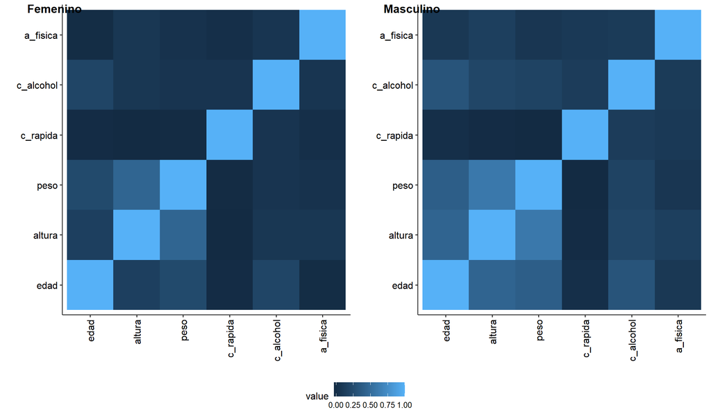

```r
#Reformateo las matrices de correlacion para
melted_cormat1 <- melt(cor_fem)
melted_cormat2 <- melt(cor_mas)

#Genero los gráficos para cada valor de genero
p1 <- ggplot(data = melted_cormat1, aes(x=Var1, y=Var2, fill=value)) +  geom_tile()+  scale_x_discrete(guide = guide_axis(angle = 90)) + xlab("")+ ylab("")


p2 <- ggplot(data = melted_cormat2, aes(x=Var1, y=Var2, fill=value)) +
  geom_tile() + scale_x_discrete(guide = guide_axis(angle = 90))+ xlab("")+ ylab("")

#Junto los gráficos para que aparezcan lado a lado
figure <- ggarrange(p1, p2,
                    labels = c("Femenino", "Masculino"),
                    ncol = 2, nrow = 1,  common.legend = TRUE, legend = "bottom")
figure
```

Las correlaciones caen en el intervalo [-0.09, 1], por lo que no hay correlaciones negativas de valores altos. En cambio sí hay varias correlaciones positivas de valores altos, en particular entre las variables edad, altura y peso.

Si quiero ver en particular las correlaciones que incluyen el peso:

```r
cor_fem[3,]
```

```
##        edad      altura        peso    c_rapida   c_alcohol    a_fisica
##  0.22702222  0.44392025  1.00000000 -0.02264047  0.04917439  0.03122441
```

```r
cor_mas[3,]
```

```
##        edad      altura        peso    c_rapida   c_alcohol    a_fisica
##  0.36039123  0.57043673  1.00000000 -0.08346171  0.13173455  0.01804150
```

La altura es la variable con mayor correlación con el peso para ambos sexos, seguida de la edad. Estas dos correlaciones son aún más grandes para el género masculino.

El consumo de comida rapida se correlaciona negativamente, en mayor medida para el género masculino.

El consumo de alcohol se correlaciona positivamente con el peso, en mayor medida para el género masculino.

Los actividad física semanal se correlaciona positivamente con el peso, y es la única correlación más acentuada en el género femenino.

## Para las categorías de la variable frecuencia de hambre mensual, analice gráficamente la distribución entérminos de frecuencia relativa de:

## a) El consumo semanal de verdura.

## b) El consumo semanal de comida grasa.

## ¿Cuáles son las principales características que observa en estos gráficos?

Genero el gráfico del consumo semanal de verdura para distintos niveles de frecuencia de hambre mensual.

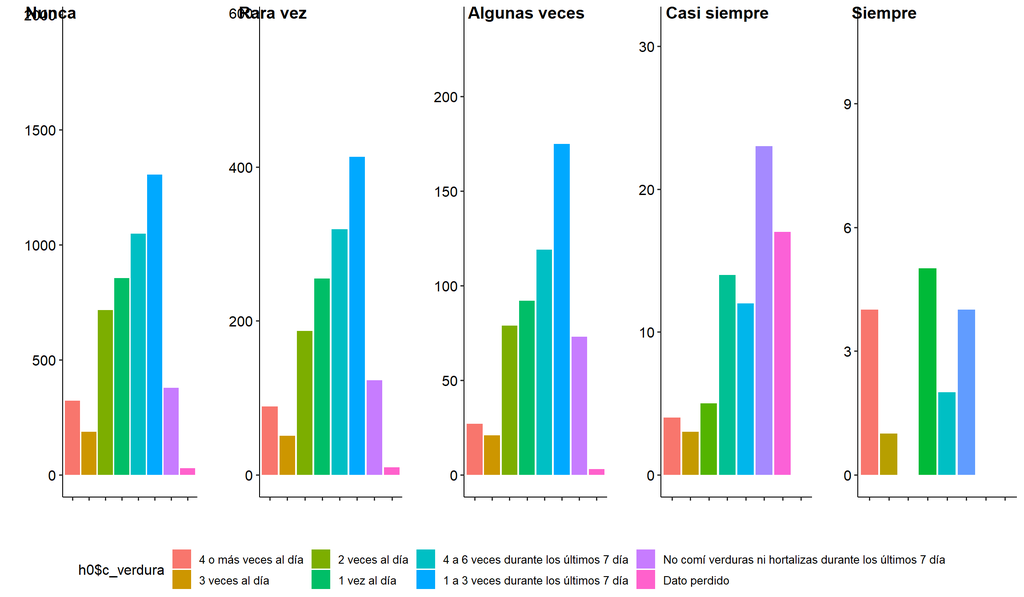

```r
#Corto los datos según el valor de f_hambre
h0=DT[f_hambre=="Nunca"]
h1=DT[f_hambre=="Rara vez"]
h2=DT[f_hambre=="Algunas veces"]
h3=DT[f_hambre=="Casi siempre"]
h4=DT[f_hambre=="Siempre"]



#Explicito el orden de los valores de c_verdura
positions <- c("4 o mA!s veces al dA-a", "3 veces al dA-a", "2 veces al dA-a", "1 vez al dA-a", "4 a 6 veces durante los Aºltimos 7 dA-as", "1 a 3 veces durante los Aºltimos 7 dA-as", "No comA- verduras ni hortalizas durante los Aºltimos 7 dA-as", "Dato perdido")

#Arreglo los acentos en los niveles
niveles <- c("4 o más veces al día", "3 veces al día", "2 veces al día", "1 vez al día", "4 a 6 veces durante los últimos 7 día", "1 a 3 veces durante los últimos 7 día", "No comí verduras ni hortalizas durante los últimos 7 día", "Dato perdido")



h0$c_verdura <- factor(h0$c_verdura, levels = positions)
h1$c_verdura <- factor(h1$c_verdura, levels = positions)
h2$c_verdura <- factor(h2$c_verdura, levels = positions)
h3$c_verdura <- factor(h3$c_verdura, levels = positions)
h4$c_verdura <- factor(h4$c_verdura, levels = positions)


#Genero los gráficos para cada nivel de f_hambre
p5=ggplot(h0, aes(x=h0$c_verdura, fill=h0$c_verdura)) +
  geom_bar(position="dodge")+ scale_x_discrete(labels = c('','','','','','','',''), limits = positions)+ xlab("") + ylab("") + ylim(0,dim(h0)[1]/2.5) + scale_fill_discrete(labels=niveles)


p6=ggplot(h1, aes(x=h1$c_verdura, fill=h1$c_verdura)) +
  geom_bar(position="dodge")+ scale_x_discrete(labels = c('','','','','','','',''), limits = positions)+ xlab("") + ylab("") + ylim(0,dim(h1)[1]/2.5) + scale_fill_discrete(labels=niveles)


p7=ggplot(h2, aes(x=h2$c_verdura, fill=h2$c_verdura)) +
  geom_bar(position="dodge")+ scale_x_discrete(labels = c('','','','','','','',''), limits = positions)+ xlab("") + ylab("") + ylim(0,dim(h2)[1]/2.5)+ scale_fill_discrete(labels=niveles)

p8=ggplot(h3, aes(x=h3$c_verdura, fill=h3$c_verdura)) +
  geom_bar(position="dodge")+ scale_x_discrete(labels = c('','','','','','','',''), limits = positions)+ xlab("") + ylab("") + ylim(0,dim(h3)[1]/2.5)+ scale_fill_discrete(labels=niveles)

p9=ggplot(h4, aes(x=h4$c_verdura, fill=h4$c_verdura)) +
  geom_bar(position="dodge")+ scale_x_discrete(labels = c('','','','','','','',''), limits = positions)+ xlab("") + ylab("") + ylim(0,dim(h4)[1]/2.5)+ scale_fill_discrete(labels=niveles)

#Junto los gráficos
figure <- ggarrange(p5, p6, p7, p8, p9,
                    labels = c("Nunca", "Rara vez", "Algunas veces", "Casi siempre", "Siempre"),
                    ncol = 5, nrow = 1,
                    common.legend = TRUE, legend = "bottom")
figure
```

```r
#Observaciones por nivel de f_hambre
c(dim(h0)[1], dim(h1)[1],dim(h2)[1],dim(h3)[1], dim(h4)[1])
```

```
## [1] 4844 1447  589   78   27
```

Se observa que la cantidad de datos va disminuyendo para mayor frecuencia de hambre. En particular “casi siempre” y “siempre tienen menos de 100 casos cada una, por lo que sus distribuciones son poco representativas.

Lo que se observa consistentemente en los primeros 3 nivéles de f_hambre, es que a medida que crece la frecuencia de hambre, disminuyen relativamente las ocurrencias de “4 o más veces al día”, y aumentan relativamente las de “1 a 3 veces durante los últimos 7 día” y de “No comí verduras ni hortalizas durante los últimos 7 día”.

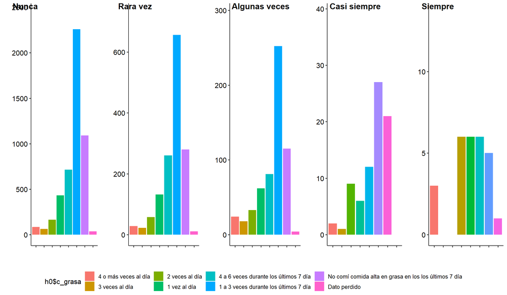

```r
#Corto los datos según el valor de f_hambre
h0=DT[f_hambre=="Nunca"]
h1=DT[f_hambre=="Rara vez"]
h2=DT[f_hambre=="Algunas veces"]
h3=DT[f_hambre=="Casi siempre"]
h4=DT[f_hambre=="Siempre"]

#Explicito el orden de los valores de c_grasa
positions <- c("4 o mA!s veces al dA-a", "3 veces al dA-a", "2 veces al dA-a", "1 vez al dA-a", "4 a 6 veces durante los Aºltimos 7 dA-as", "1 a 3 veces durante los Aºltimos 7 dA-as", "No comA- comida alta en grasa en los Aºltimos 7 dA-as", "Dato perdido")

#Arreglo los acentos en los niveles
niveles <- c("4 o más veces al día", "3 veces al día", "2 veces al día", "1 vez al día", "4 a 6 veces durante los últimos 7 día", "1 a 3 veces durante los últimos 7 día", "No comí comida alta en grasa en los los últimos 7 día", "Dato perdido")

h0$c_grasa <- factor(h0$c_grasa, levels = positions)
h1$c_grasa <- factor(h1$c_grasa, levels = positions)
h2$c_grasa <- factor(h2$c_grasa, levels = positions)
h3$c_grasa <- factor(h3$c_grasa, levels = positions)
h4$c_grasa <- factor(h4$c_grasa, levels = positions)

#Genero los gráficos para cada nivel de f_hambre
p0=ggplot(h0, aes(x=h0$c_grasa, fill=h0$c_grasa)) +
  geom_bar(position="dodge")+ scale_x_discrete(labels = c('','','','','','','',''), limits = positions)+ xlab("") + ylab("") + ylim(0,dim(h0)[1]/2) + scale_fill_discrete(labels=niveles)

p1=ggplot(h1, aes(x=h1$c_grasa, fill=h1$c_grasa)) +
  geom_bar(position="dodge")+ scale_x_discrete(labels = c('','','','','','','',''), limits = positions)+ xlab("") + ylab("") + ylim(0,dim(h1)[1]/2)+ scale_fill_discrete(labels=niveles)

p2=ggplot(h2, aes(x=h2$c_grasa, fill=h2$c_grasa)) +
  geom_bar(position="dodge")+ scale_x_discrete(labels = c('','','','','','','',''), limits = positions)+ xlab("") + ylab("") + ylim(0,dim(h2)[1]/2)+ scale_fill_discrete(labels=niveles)

p3=ggplot(h3, aes(x=h3$c_grasa, fill=h3$c_grasa)) +
  geom_bar(position="dodge")+ scale_x_discrete(labels = c('','','','','','','',''), limits = positions)+ xlab("") + ylab("") + ylim(0,dim(h3)[1]/2)+ scale_fill_discrete(labels=niveles)

p4=ggplot(h4, aes(x=h4$c_grasa, fill=h4$c_grasa)) +
  geom_bar(position="dodge")+ scale_x_discrete(labels = c('','','','','','','',''), limits = positions)+ xlab("") + ylab("") + ylim(0,dim(h4)[1]/2)+ scale_fill_discrete(labels=niveles)

#Junto los gráficos
figure <- ggarrange(p0, p1, p2, p3, p4,
                    labels = c("Nunca", "Rara vez", "Algunas veces", "Casi siempre", "Siempre"),
                    ncol = 5, nrow = 1,
                    common.legend = TRUE, legend = "bottom")
figure
```

```r
as.data.frame(table(h0$c_grasa))
```

```
##                                                    Var1 Freq
## 1                                4 o mA!s veces al dA-a   84
## 2                                       3 veces al dA-a   63
## 3                                       2 veces al dA-a  165
## 4                                         1 vez al dA-a  432
## 5              4 a 6 veces durante los Aºltimos 7 dA-as  715
## 6              1 a 3 veces durante los Aºltimos 7 dA-as 2259
## 7 No comA- comida alta en grasa en los Aºltimos 7 dA-as 1091
## 8                                          Dato perdido   35
```

Se observa en los primeros 3 nivéles de f_hambre que a medida que crece la frecuencia de hambre, aumentan la proporción de datos que corresponden a comida alta en grasa 1 vez, 2 veces, 3 veces y 4 o más veces al día. Y disminuyen en cambio las proporciones de “1 a 3 veces durante los últimos 7 día” y “No comí comida alta en grasa en los los últimos 7 día”.

### 2) Modelo inicial

### Se plantea que una primera alternativa para modelar el peso es:

### E(peso) = β0 +β1altura+β2edad+β3genero+β4diasActividadF isicaSemanal+β5consumoDiarioAlcohol

### ¿Cuál es la interpretación de cada uno de los coeficientes estimados? ¿Son significativos? ¿El modelo resulta significativo para explicar el peso? ¿Qué porcentaje de la variabilidad explica el modelo?

Realizamos el modelo lineal multiple:

```r
#Ajustamos un modelo lineal múltiple
modelo_inicial <- lm(peso ~ altura+edad+genero+a_fisica+c_alcohol, data = DT)
#Resumen del modelo
summary(modelo_inicial)
```

```
##
## Call:
## lm(formula = peso ~ altura + edad + genero + a_fisica + c_alcohol,
##     data = DT)
##
## Residuals:
##     Min      1Q  Median      3Q     Max
## -28.014  -6.527  -1.104   5.050  76.143
##
## Coefficients:
##                   Estimate Std. Error t value Pr(>|t|)
## (Intercept)     -68.922688   2.338054 -29.479  < 2e-16 ***
## altura            0.650607   0.014380  45.245  < 2e-16 ***
## edad              1.406727   0.093851  14.989  < 2e-16 ***
## generoMasculino   1.262644   0.272828   4.628 3.76e-06 ***
## a_fisica         -0.087391   0.049929  -1.750   0.0801 .
## c_alcohol         0.007271   0.061386   0.118   0.9057
## ---
## Signif. codes:  0 '***' 0.001 '**' 0.01 '*' 0.05 '.' 0.1 ' ' 1
##
## Residual standard error: 9.914 on 7018 degrees of freedom
## Multiple R-squared:  0.3544, Adjusted R-squared:  0.3539
## F-statistic: 770.4 on 5 and 7018 DF,  p-value: < 2.2e-16
```

Para introducir la variable categórica de género, el modelo mapea por default masculino a 1 y femenino a 0. Se podría hacer la elección inversa, y lo único que cambiaría sería los valores de beta_0 y beta_3, así como su interpretación.

Con esta elección el coeficiente beta_0 correspondería al peso de una mujer de edad, altura, frecuencia de actividad física y de consumo de alcohol iguales a cero, que no es un caso realista para estas variables.

El coeficiente beta_3 se corresponde a la diferencia de peso predicha entre un hombre y una mujer que tienen la misma edad, altura, a_fisica y c_alcohol.

beta_1, beta_2, beta_4 y beta_5 son las constantes multiplicativas que predicen la variación del peso en función del crecimiento de la edad, altura frecuencia de actividad física y de consumo de alcohol respectivamente, manteniendo las demas variables fijas.

Si se elige como corte un p-valor de 0.05, solo los coeficientes beta_0, beta_1, beta_2 y beta_3 son significativos.

En total, el modelo sí resulta significativo, con un p-valor de orden de magnitud de -16, y explica una variabilidad de 0.3544.

### 3) Modelo categóricas

### Se sugiere probar un modelo que incopore el consumo semanal de snacks y una interacción entre el género y la edad, en lugar de actividad física y consumo de alcohol:

### E(peso) = β0 + β1altura + β2edad + β3genero + β4consumoSemanalSnacks + β5genero · edad

### Además se pide explícitamente que la categoría “No comí comida salada o snacks en los últimos 7 días” de la variable consumoSemanalSnacks se encuentre como nivel/categoría basal.

Primero establezco como nivel basal a “No comí comida salada o snacks…”:

```r
#Defino a la variable como factor
DT$c_snacks <- as.factor(DT$c_snacks)
DT_test$c_snacks <- as.factor(DT_test$c_snacks)


#Redefino el baseline
DT$c_snacks <- relevel(DT$c_snacks, ref="No comA- comida salada o snacks en los Aºltimos 7 dA-as")

DT_test$c_snacks <- relevel(DT_test$c_snacks, ref="No comA- comida salada o snacks en los Aºltimos 7 dA-as")
```

Y realizamos el modelo lineal, agregando también el producto de genero y edad:

```r
#Ajustamos un modelo lineal múltiple
modelo_categorias <- lm(peso ~ altura+edad+genero+c_snacks+edad*genero, data = DT)
# Resumen del modelo
summary(modelo_categorias)
```

```
##
## Call:
## lm(formula = peso ~ altura + edad + genero + c_snacks + edad *
##     genero, data = DT)
##
## Residuals:
##     Min      1Q  Median      3Q     Max
## -29.005  -6.452  -1.157   5.052  75.767
##
## Coefficients:
##                                                   Estimate Std. Error t value
## (Intercept)                                      -64.19940    2.82849 -22.697
## altura                                             0.64292    0.01453  44.250
## edad                                               1.22309    0.12102  10.106
## generoMasculino                                   -4.61150    2.67877  -1.722
## c_snacks1 a 3 veces durante los Aºltimos 7 dA-as  -1.35163    0.27645  -4.889
## c_snacks1 vez al dA-a                             -0.60788    0.45601  -1.333
## c_snacks2 veces al dA-a                           -1.09466    0.68457  -1.599
## c_snacks3 veces al dA-a                           -1.27596    1.01150  -1.261
## c_snacks4 a 6 veces durante los Aºltimos 7 dA-as  -2.27004    0.44992  -5.045
## c_snacks4 o mA!s veces al dA-a                    -2.56697    0.88112  -2.913
## c_snacksDato perdido                              -4.44042    1.95125  -2.276
## edad:generoMasculino                               0.39146    0.17902   2.187
##                                                  Pr(>|t|)
## (Intercept)                                       < 2e-16 ***
## altura                                            < 2e-16 ***
## edad                                              < 2e-16 ***
## generoMasculino                                   0.08520 .
## c_snacks1 a 3 veces durante los Aºltimos 7 dA-as 1.03e-06 ***
## c_snacks1 vez al dA-a                             0.18257
## c_snacks2 veces al dA-a                           0.10985
## c_snacks3 veces al dA-a                           0.20719
## c_snacks4 a 6 veces durante los Aºltimos 7 dA-as 4.64e-07 ***
## c_snacks4 o mA!s veces al dA-a                    0.00359 **
## c_snacksDato perdido                              0.02289 *
## edad:generoMasculino                              0.02880 *
## ---
## Signif. codes:  0 '***' 0.001 '**' 0.01 '*' 0.05 '.' 0.1 ' ' 1
##
## Residual standard error: 9.887 on 7012 degrees of freedom
## Multiple R-squared:  0.3585, Adjusted R-squared:  0.3575
## F-statistic: 356.3 on 11 and 7012 DF,  p-value: < 2.2e-16
```

### ¿Cuál es la interpretación de los coeficientes estimados para las categorías de consumoSemanalSnacks y genero . edad? ¿Son significativas? ¿Qué porcentaje de la variabilidad explica el modelo?

El coeficiente beta_5 corresponde a la diferencia predicha entre hombres y mujeres de la constante multiplicativa que relaciona la variabción de peso en función de la edad, manteniendo las demás variables fijas. Para mujeres, esta constante multiplicativa se aproxima con beta_2, para hombres con beta_2+beta_5. El coeficiente es significativo para nuestra eleccion de umbral de 0.05, con un p-valor de 0.02880.

En total, el modelo explica una variabilidad de 0.3585, mayor a la del modelo anterior. Su R^2 ajustado también es mayor, por lo que la mayor explicación no se debe únicamente a la mayor cantidad de parámetros.

### En caso de detectar que existen categorías no significativas de la variable consumoSemanalSnacks evaluar si la variable es significativa en su conjunto y, en caso afirmativo, proponer una redefinición de las mismas que permita obtener una mayor proporción de categorías significativas individualmente. Luego, analizar si existen cambios en la variabilidad explicada por el modelo.

Las categorías correspondientes a 1, 2 y 3 veces al día no son significativas. Para probar si la variable en conjunto es significativa hago un likelihood ratio test.

```r
#La hipótesis nula es el modelo sin c_snacks
modelo_0 <- lm(peso ~ altura+edad+genero+edad*genero, data = DT)

#Con likelihood
L0 <- logLik(modelo_0)

#El modelo con la variable categórica es la hipótesis alternativa


#Con likelihood
L1 <- logLik(modelo_categorias)

#Calculo el p-valor
1-pchisq(2*(L1-L0),df=1)
```

```
## 'log Lik.' 3.622702e-11 (df=13)
```

La variable es, en conjunto, significativa.

Propongo entonces una redefinición de las categorías juntando aquellas 3 que no son significativas en un mismo nivel.

```r
#Junto estos 3 niveles
DT$c_snacks <- fct_collapse(DT$c_snacks, "1 a 3 veces al dia" = c("1 vez al dA-a","3 veces al dA-a", "2 veces al dA-a"))
DT_test$c_snacks <- fct_collapse(DT_test$c_snacks, "1 a 3 veces al dia" = c("1 vez al dA-a","3 veces al dA-a", "2 veces al dA-a"))

#Ajustamos un modelo lineal múltiple
modelo_categorias <- lm(peso ~ altura+edad+genero+c_snacks+edad*genero, data = DT)

#Resumen del modelo
summary(modelo_categorias)
```

```
##
## Call:
## lm(formula = peso ~ altura + edad + genero + c_snacks + edad *
##     genero, data = DT)
##
## Residuals:
##     Min      1Q  Median      3Q     Max
## -28.999  -6.435  -1.150   5.068  75.765
##
## Coefficients:
##                                                   Estimate Std. Error t value
## (Intercept)                                      -64.18372    2.82814 -22.695
## altura                                             0.64291    0.01453  44.256
## edad                                               1.22224    0.12100  10.101
## generoMasculino                                   -4.58512    2.67831  -1.712
## c_snacks1 a 3 veces durante los Aºltimos 7 dA-as  -1.35167    0.27642  -4.890
## c_snacks1 a 3 veces al dia                        -0.80004    0.38771  -2.063
## c_snacks4 a 6 veces durante los Aºltimos 7 dA-as  -2.27038    0.44988  -5.047
## c_snacks4 o mA!s veces al dA-a                    -2.56729    0.88104  -2.914
## c_snacksDato perdido                              -4.44071    1.95106  -2.276
## edad:generoMasculino                               0.38961    0.17899   2.177
##                                                  Pr(>|t|)
## (Intercept)                                       < 2e-16 ***
## altura                                            < 2e-16 ***
## edad                                              < 2e-16 ***
## generoMasculino                                   0.08695 .
## c_snacks1 a 3 veces durante los Aºltimos 7 dA-as 1.03e-06 ***
## c_snacks1 a 3 veces al dia                        0.03910 *
## c_snacks4 a 6 veces durante los Aºltimos 7 dA-as 4.61e-07 ***
## c_snacks4 o mA!s veces al dA-a                    0.00358 **
## c_snacksDato perdido                              0.02287 *
## edad:generoMasculino                              0.02954 *
## ---
## Signif. codes:  0 '***' 0.001 '**' 0.01 '*' 0.05 '.' 0.1 ' ' 1
##
## Residual standard error: 9.886 on 7014 degrees of freedom
## Multiple R-squared:  0.3585, Adjusted R-squared:  0.3576
## F-statistic: 435.5 on 9 and 7014 DF,  p-value: < 2.2e-16
```

En este nuevo modelo, todas los niveles de c_snacks son significativos. La variabilidad explicada disminuye por tener menos variables, pero en forma casi despreciable de 0.3585222713 a 0.3584614819. El R^2 ajustado en cambio aumenta mínimamente.

### Realizar 2 modelos lineales múltiples adicionales y explicar brevemente la lógica detrás de los mismos (se valorará la creación y/o inclusión de variables nuevas).

Modelo propio 1) Observo que en el dataset hay 5 variables ordinales que describen la frecuencia de consumos de ciertos tipos alimentos. Todas ellas tienen 8 niveles que cubren los mismos intervalos de frecuencia, que van desde cero a más de de 4 veces diarias.

Agrego además las 3 variables numéricas todavía no probadas, c_rapida, c_alcohol y a_fisica.

```r
#Defino una funcion que, a partir de nuestras varaibles categóricas, cree una variable numérica correspondiente
numerizar  <- function( variable )
{
#Por suerte los niveles se llaman igual entre variables, excepto por el nivel de frecuencia cero. Este último no es necesario llamarlo en la función, ya que en casos de que se dé este nivel, dejamos la nueva variable numérica igual a cero

DT[, "new" := (1.5/7)*(get(variable) == "1 a 3 veces durante los Aºltimos 7 dA-as") +(5/7)*(get(variable) == "4 a 6 veces durante los Aºltimos 7 dA-as")+1*(get(variable) == "1 vez al dA-a")+2*(get(variable) == "2 veces al dA-a")+3*(get(variable) == "3 veces al dA-a")+4.5*(get(variable) == "4 o mA!s veces al dA-a")]

return(DT$new)

}


numerizar_test  <- function( variable )
{

DT_test[, "new" := (1.5/7)*(get(variable) == "1 a 3 veces durante los Aºltimos 7 dA-as") +(5/7)*(get(variable) == "4 a 6 veces durante los Aºltimos 7 dA-as")+1*(get(variable) == "1 vez al dA-a")+2*(get(variable) == "2 veces al dA-a")+3*(get(variable) == "3 veces al dA-a")+4.5*(get(variable) == "4 o mA!s veces al dA-a")]

return(DT_test$new)

}
```

Ahora utilizo la función

```r
#Creo las 5 nuevas variables numéricas
DT[,"n_frutas"] <- numerizar("c_frutas")
DT[,"n_snacks"] <- numerizar("c_snacks")
DT[,"n_gaseosa"] <- numerizar("c_gaseosa")
DT[,"n_verdura"] <- numerizar("c_verdura")
DT[,"n_grasa"] <- numerizar("c_grasa")
DT[,"n_snacks"] <- numerizar("c_snacks")

DT_test[,"n_frutas"] <- numerizar_test("c_frutas")
DT_test[,"n_snacks"] <- numerizar_test("c_snacks")
DT_test[,"n_gaseosa"] <- numerizar_test("c_gaseosa")
DT_test[,"n_verdura"] <- numerizar_test("c_verdura")
DT_test[,"n_grasa"] <- numerizar_test("c_grasa")
DT_test[,"n_snacks"] <- numerizar_test("c_snacks")

#Ajustamos un modelo lineal múltiple
modelo_propio_1 <- lm(peso ~ altura + genero + edad + n_gaseosa + n_verdura +n_snacks +n_frutas +n_grasa + n_snacks +  c_rapida + c_alcohol + a_fisica, data = DT)

#Resumen del modelo
summary(modelo_propio_1)
```

```
##
## Call:
## lm(formula = peso ~ altura + genero + edad + n_gaseosa + n_verdura +
##     n_snacks + n_frutas + n_grasa + n_snacks + c_rapida + c_alcohol +
##     a_fisica, data = DT)
##
## Residuals:
##     Min      1Q  Median      3Q     Max
## -28.423  -6.474  -1.065   4.994  75.673
##
## Coefficients:
##                  Estimate Std. Error t value Pr(>|t|)
## (Intercept)     -67.60224    2.35845 -28.664  < 2e-16 ***
## altura            0.64627    0.01440  44.882  < 2e-16 ***
## generoMasculino   1.31983    0.27311   4.833 1.38e-06 ***
## edad              1.39067    0.09392  14.808  < 2e-16 ***
## n_gaseosa        -0.34100    0.09781  -3.486 0.000493 ***
## n_verdura         0.06686    0.10833   0.617 0.537119
## n_snacks         -0.52604    0.19622  -2.681 0.007361 **
## n_frutas         -0.05015    0.10848  -0.462 0.643870
## n_grasa           0.09909    0.16089   0.616 0.537990
## c_rapida         -0.10808    0.08991  -1.202 0.229392
## c_alcohol         0.03851    0.06186   0.623 0.533619
## a_fisica         -0.08928    0.05070  -1.761 0.078290 .
## ---
## Signif. codes:  0 '***' 0.001 '**' 0.01 '*' 0.05 '.' 0.1 ' ' 1
##
## Residual standard error: 9.899 on 7012 degrees of freedom
## Multiple R-squared:  0.3569, Adjusted R-squared:  0.3559
## F-statistic: 353.7 on 11 and 7012 DF,  p-value: < 2.2e-16
```

Modelo propio 2) En este modelo trataremos de aplicar lo aprendido en los puntos anteriores.

Viendo las matrices de correlación separada por generos, observamos que las correlaciones peso-altura y peso-edad cambian considerablemente entre hombres y mujeres. Proponemos entonces para comenzar un modelo que tenga en cuenta ambas variables separadas por género.

```r
#Ajustamos un modelo lineal múltiple
modelo_l <- lm(peso ~ altura*genero + edad*genero, data = DT)

#Resumen del modelo
summary(modelo_l)
```

```
##
## Call:
## lm(formula = peso ~ altura * genero + edad * genero, data = DT)
##
## Residuals:
##     Min      1Q  Median      3Q     Max
## -28.380  -6.534  -1.119   5.129  76.282
##
## Coefficients:
##                         Estimate Std. Error t value Pr(>|t|)
## (Intercept)            -57.62532    3.75610 -15.342  < 2e-16 ***
## altura                   0.58986    0.02219  26.586  < 2e-16 ***
## generoMasculino        -17.28651    4.85596  -3.560 0.000374 ***
## edad                     1.28559    0.12184  10.551  < 2e-16 ***
## altura:generoMasculino   0.09304    0.02936   3.169 0.001536 **
## generoMasculino:edad     0.21964    0.18624   1.179 0.238304
## ---
## Signif. codes:  0 '***' 0.001 '**' 0.01 '*' 0.05 '.' 0.1 ' ' 1
##
## Residual standard error: 9.906 on 7018 degrees of freedom
## Multiple R-squared:  0.3554, Adjusted R-squared:  0.355
## F-statistic:   774 on 5 and 7018 DF,  p-value: < 2.2e-16
```

Vemos que el parámetro generoMasculino:edad no es significativo, como sí lo era en el punto anterior. Puede estar ocurriendo que la inclusión de altura:generoMasculino ya explique mejor la diferencia en pesos entre los dos géneros. En todo caso removemos genero*edad del modelo.

Luego agregamos al modelo c_snacks, con la redefinición de sus niveles anterior. Por último redefinimos el nivel basal de c_gasesosa a “no tomé gaseosa…” y la agregamos:

```r
#Defino a la variable como factor
DT$c_gaseosa <- as.factor(DT$c_gaseosa)
DT_test$c_gaseosa <- as.factor(DT_test$c_gaseosa)

#Redefino el baseline
DT$c_gaseosa <- relevel(DT$c_gaseosa, ref="No tomA(C) gaseosas en los Aºltimos 7 dA-as")
DT_test$c_gaseosa <- relevel(DT_test$c_gaseosa, ref="No tomA(C) gaseosas en los Aºltimos 7 dA-as")


#Ajustamos un modelo lineal múltiple
modelo_l1 <- lm(peso ~ altura*genero + edad + c_gaseosa + c_snacks, data = DT)

#Resumen del modelo
summary(modelo_l1)
```

```
##
## Call:
## lm(formula = peso ~ altura * genero + edad + c_gaseosa + c_snacks,
##     data = DT)
##
## Residuals:
##     Min      1Q  Median      3Q     Max
## -29.494  -6.414  -1.206   5.061  75.084
##
## Coefficients:
##                                                    Estimate Std. Error t value
## (Intercept)                                       -57.06506    3.66584 -15.567
## altura                                              0.58732    0.02204  26.647
## generoMasculino                                   -15.16545    4.62300  -3.280
## edad                                                1.36628    0.09193  14.862
## c_gaseosa1 a 3 veces durante los Aºltimos 7 dA-as  -0.41534    0.32968  -1.260
## c_gaseosa1 vez al dA-a                             -0.54137    0.46239  -1.171
## c_gaseosa2 veces al dA-a                           -1.83307    0.51857  -3.535
## c_gaseosa3 veces al dA-a                           -0.44181    0.65305  -0.677
## c_gaseosa4 a 6 veces durante los Aºltimos 7 dA-as  -0.51435    0.41063  -1.253
## c_gaseosa4 o mA!s veces al dA-a                    -1.64686    0.50254  -3.277
## c_gaseosaDato perdido                              -3.44074    1.99870  -1.721
## c_snacks1 a 3 veces durante los Aºltimos 7 dA-as   -1.21569    0.28128  -4.322
## c_snacks1 a 3 veces al dia                         -0.39299    0.40681  -0.966
## c_snacks4 a 6 veces durante los Aºltimos 7 dA-as   -2.02569    0.45937  -4.410
## c_snacks4 o mA!s veces al dA-a                     -1.93377    0.89732  -2.155
## c_snacksDato perdido                               -4.03417    1.95651  -2.062
## altura:generoMasculino                              0.10051    0.02819   3.566
##                                                   Pr(>|t|)
## (Intercept)                                        < 2e-16 ***
## altura                                             < 2e-16 ***
## generoMasculino                                   0.001042 **
## edad                                               < 2e-16 ***
## c_gaseosa1 a 3 veces durante los Aºltimos 7 dA-as 0.207769
## c_gaseosa1 vez al dA-a                            0.241715
## c_gaseosa2 veces al dA-a                          0.000411 ***
## c_gaseosa3 veces al dA-a                          0.498724
## c_gaseosa4 a 6 veces durante los Aºltimos 7 dA-as 0.210395
## c_gaseosa4 o mA!s veces al dA-a                   0.001054 **
## c_gaseosaDato perdido                             0.085206 .
## c_snacks1 a 3 veces durante los Aºltimos 7 dA-as  1.57e-05 ***
## c_snacks1 a 3 veces al dia                        0.334063
## c_snacks4 a 6 veces durante los Aºltimos 7 dA-as  1.05e-05 ***
## c_snacks4 o mA!s veces al dA-a                    0.031193 *
## c_snacksDato perdido                              0.039252 *
## altura:generoMasculino                            0.000365 ***
## ---
## Signif. codes:  0 '***' 0.001 '**' 0.01 '*' 0.05 '.' 0.1 ' ' 1
##
## Residual standard error: 9.87 on 7007 degrees of freedom
## Multiple R-squared:  0.3612, Adjusted R-squared:  0.3597
## F-statistic: 247.6 on 16 and 7007 DF,  p-value: < 2.2e-16
```

Observamos que los 3 niveles más bajos de c_gaseosa no son significativos, por lo que los agrupamos con el nivel basal. Lo mismo hacemos para el nivel “dato perdido”.

```r
#Junto estos 3 niveles
DT$c_gaseosa <- fct_collapse(DT$c_gaseosa, "No tomA(C) gaseosas en los Aºltimos 7 dA-as" = c("Dato perdido", "No tomA(C) gaseosas en los Aºltimos 7 dA-as", "1 vez al dA-a","1 a 3 veces durante los Aºltimos 7 dA-as", "4 a 6 veces durante los Aºltimos 7 dA-as"), "2 o 3 veces al dia" = c("2 veces al dA-a","3 veces al dA-a"))

DT_test$c_gaseosa <- fct_collapse(DT_test$c_gaseosa, "No tomA(C) gaseosas en los Aºltimos 7 dA-as" = c("Dato perdido", "No tomA(C) gaseosas en los Aºltimos 7 dA-as", "1 vez al dA-a","1 a 3 veces durante los Aºltimos 7 dA-as", "4 a 6 veces durante los Aºltimos 7 dA-as"), "2 o 3 veces al dia" = c("2 veces al dA-a","3 veces al dA-a"))

#Ajustamos un modelo lineal múltiple
modelo_propio_2 <- lm(peso ~ altura*genero + edad + c_gaseosa + c_snacks, data = DT)



#Resumen del modelo
summary(modelo_propio_2)
```

```
##
## Call:
## lm(formula = peso ~ altura * genero + edad + c_gaseosa + c_snacks,
##     data = DT)
##
## Residuals:
##     Min      1Q  Median      3Q     Max
## -29.171  -6.418  -1.192   5.048  74.988
##
## Coefficients:
##                                                   Estimate Std. Error t value
## (Intercept)                                      -57.40494    3.65594 -15.702
## altura                                             0.58774    0.02203  26.673
## generoMasculino                                  -14.93395    4.62204  -3.231
## edad                                               1.36655    0.09194  14.863
## c_gaseosa2 o 3 veces al dia                       -0.96866    0.38337  -2.527
## c_gaseosa4 o mA!s veces al dA-a                   -1.28042    0.44577  -2.872
## c_snacks1 a 3 veces durante los Aºltimos 7 dA-as  -1.30121    0.27626  -4.710
## c_snacks1 a 3 veces al dia                        -0.48913    0.39677  -1.233
## c_snacks4 a 6 veces durante los Aºltimos 7 dA-as  -2.16544    0.45010  -4.811
## c_snacks4 o mA!s veces al dA-a                    -2.02434    0.89541  -2.261
## c_snacksDato perdido                              -4.28700    1.94870  -2.200
## altura:generoMasculino                             0.09889    0.02818   3.509
##                                                  Pr(>|t|)
## (Intercept)                                       < 2e-16 ***
## altura                                            < 2e-16 ***
## generoMasculino                                  0.001239 **
## edad                                              < 2e-16 ***
## c_gaseosa2 o 3 veces al dia                      0.011535 *
## c_gaseosa4 o mA!s veces al dA-a                  0.004086 **
## c_snacks1 a 3 veces durante los Aºltimos 7 dA-as 2.52e-06 ***
## c_snacks1 a 3 veces al dia                       0.217705
## c_snacks4 a 6 veces durante los Aºltimos 7 dA-as 1.53e-06 ***
## c_snacks4 o mA!s veces al dA-a                   0.023802 *
## c_snacksDato perdido                             0.027844 *
## altura:generoMasculino                           0.000452 ***
## ---
## Signif. codes:  0 '***' 0.001 '**' 0.01 '*' 0.05 '.' 0.1 ' ' 1
##
## Residual standard error: 9.872 on 7012 degrees of freedom
## Multiple R-squared:  0.3604, Adjusted R-squared:  0.3594
## F-statistic: 359.2 on 11 and 7012 DF,  p-value: < 2.2e-16
```

### Evaluar la performance del modelo inicial, el modelo categóricas con las categorías redefinidas de la variable consumoSemanalSnacks y los modelos desarrollados en este punto en el dataset de entrenamiento y evaluación (usar dataset “encuesta_salud_test.csv”). La evaluación de performance consiste en comparar la performance en términos del R cuadrado ajustado, RMSE y MAE sobre el set de entrenamiento y en términos de RMSE y MAE sobre el set de evaluación. ¿Cuál es el mejor modelo para nuestro objetivo de predecir el peso? ¿Por qué?

```r
#obtengo los valores reales
actual_train <- DT$peso
actual_test <- DT_test$peso

#Obtengo los valores predichos
predicted_train_ini <- predict.lm(modelo_inicial, DT)
predicted_train_cat <- predict.lm(modelo_categorias, DT)
predicted_train_pr1 <- predict.lm(modelo_propio_1, DT)
predicted_train_pr2 <- predict.lm(modelo_propio_2, DT)

predicted_test_ini <- predict.lm(modelo_inicial, DT_test)
predicted_test_cat <- predict.lm(modelo_categorias, DT_test)
predicted_test_pr1 <- predict.lm(modelo_propio_1, DT_test)
predicted_test_pr2 <- predict.lm(modelo_propio_2, DT_test)
```